# ANOVA y contrastes ortogonales para la producción de arroz

Dr. Byron González

2026-09-11

# 1 Introducción

La estrategia es:

1. Importar y revisar los datos;
2. Convertir el tratamiento en un factor;
3. Ajustar el ANOVA global;
4. Definir contrastes que respondan preguntas específicas;
5. Comprobar que los contrastes sean ortogonales;
6. Estimar e interpretar cada comparación.

# 2 Preparación

## 2.1 Paquetes

Se cargan los paquetes necesarios. `readxl` importa el archivo de Excel, `car` ofrece herramientas auxiliares para diagnóstico, y `multcomp` permite probar contrastes lineales mediante `glht()`. `dplyr` queda disponible para posibles resúmenes descriptivos.

```r
paquetes <- c("readxl", "dplyr", "car", "multcomp")

instalar_si_falta <- function(paquete) {
  if (!requireNamespace(paquete, quietly = TRUE)) {
    install.packages(paquete)
  }
}

invisible(lapply(paquetes, instalar_si_falta))
invisible(lapply(paquetes, library, character.only = TRUE))
```

## 2.2 Importación y revisión inicial

Se lee la hoja de cálculo ubicada en la misma carpeta que este documento y se muestran las primeras observaciones. La variable respuesta es `prod_arroz`; `rep` identifica la repetición y `trat` identifica el tratamiento.

```r
arrozc <- read_excel("arrozcontrast.xlsx")
head(arrozc)
```

```
## # A tibble: 6 × 3
##   trat  rep   prod_arroz
##   <chr> <chr>      <dbl>
## 1 1     1           57.2
## 2 1     2           51.1
## 3 1     3           48.5
## 4 1     4           54.9
## 5 2     1           40.6
## 6 2     2           43
```

```r
str(arrozc)
```

```
## tibble [20 × 3] (S3: tbl_df/tbl/data.frame)
##  $ trat      : chr [1:20] "1" "1" "1" "1" ...
##  $ rep       : chr [1:20] "1" "2" "3" "4" ...
##  $ prod_arroz: num [1:20] 57.2 51.1 48.5 54.9 40.6 43 52.2 32.3 36.9 29 ...
```

```r
summary(arrozc)
```

```
##      trat               rep              prod_arroz
##  Length:20          Length:20          Min.   :17.00
##  Class :character   Class :character   1st Qu.:31.02
##  Mode  :character   Mode  :character   Median :36.95
##                                        Mean   :37.76
##                                        3rd Qu.:44.83
##                                        Max.   :57.20
```

# 3 Organización de las variables

ANOVA necesita que el tratamiento se interprete como una variable categórica. La conversión a factor evita que R trate sus códigos como valores numéricos con una relación lineal. La repetición también se convierte en factor para conservar su papel de identificador experimental.

```r
arrozc$rep <- as.factor(arrozc$rep)
arrozc$trat <- as.factor(arrozc$trat)

levels(arrozc$trat)
```

```
## [1] "1" "2" "3" "4" "5"
```

```r
table(arrozc$trat)
```

```
##
## 1 2 3 4 5
## 4 4 4 4 4
```

# 4 ANOVA de un factor

## 4.1 Modelo estadístico

El modelo ajustado es:

$$Y_{ij} = \mu + \tau_i + \varepsilon_{ij},$$

where $Y_{ij}$ es la producción observada, $\mu$ es la media general, $\tau_i$ es el efecto del tratamiento $i$ y $\varepsilon_{ij}$ es el error aleatorio.

La hipótesis global es:

- $H_0$: todas las medias de tratamiento son iguales;
- $H_A$: al menos una media de tratamiento difiere.

El siguiente chunk ajusta el modelo y muestra la tabla ANOVA. Este contraste global responde si existe evidencia de diferencias, pero no indica todavía qué grupos son responsables de ellas.

```r
modelo <- aov(prod_arroz ~ trat, data = arrozc)
summary(modelo)
```

```
##             Df Sum Sq Mean Sq F value   Pr(>F)
## trat         4 2041.5   510.4   19.38 8.64e-06 ***
## Residuals   15  395.1    26.3
## ---
## Signif. codes:  0 '***' 0.001 '**' 0.01 '*' 0.05 '.' 0.1 ' ' 1
```

## 4.2 Medias por tratamiento

Las medias ayudan a contextualizar los contrastes posteriores. No sustituyen la prueba inferencial, porque la decisión debe considerar también la variabilidad residual y los grados de libertad del modelo.

```r
aggregate(prod_arroz ~ trat, data = arrozc, FUN = mean)
```

```
##   trat prod_arroz
## 1    1     52.925
## 2    2     42.025
## 3    3     34.150
## 4    4     21.975
## 5    5     37.700
```

```r
aggregate(prod_arroz ~ trat, data = arrozc, FUN = sd)
```

```
##   trat prod_arroz
## 1    1   3.876747
## 2    2   8.187134
## 3    3   3.759876
## 4    4   3.360927
## 5    5   4.920027
```

## 4.3 Diagnóstico básico

Los supuestos habituales del ANOVA son independencia, normalidad aproximada de los residuos y homogeneidad de varianzas. Los gráficos permiten detectar patrones que justificarían una revisión del modelo.

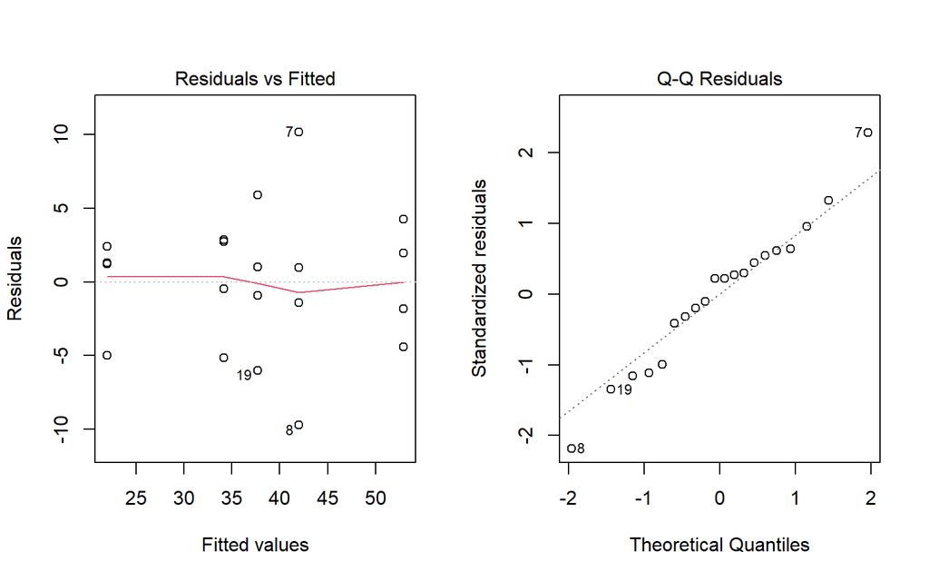

```r
par(mfrow = c(1, 2))
plot(modelo, which = 1)
plot(modelo, which = 2)
```

```r
par(mfrow = c(1, 1))
```

# 5 Contrastes ortogonales

## 5.1 Qué es un contraste

Un contraste lineal de las medias de tratamiento tiene la forma:

$$L = \sum_{i=1}^{k} c_i\bar{Y}_i,$$

con la restricción $\sum_i c_i = 0$. Los coeficientes $c_i$ determinan qué medias se comparan y con qué ponderación.

En este análisis se plantean cuatro preguntas:

| Contraste | Comparación | Coeficientes |
| --- | --- | --- |
| C1 | Nitratos frente a urea y sulfato | $(2, 2, 2, -3, -3)$ |
| C2 | Nitrato de calcio y sodio frente a nitrato de amonio | $(1, 1, -2, 0, 0)$ |
| C3 | Nitrato de calcio frente a nitrato de sodio | $(1, -1, 0, 0, 0)$ |
| C4 | Urea frente a sulfato | $(0, 0, 0, 1, -1)$ |

El orden de los coeficientes es el orden de `levels(arrozc$trat)`. Por ello, conviene revisar los niveles antes de interpretar los signos o las etiquetas.

## 5.2 Construcción de la matriz

Cada fila representa un contraste y cada columna corresponde a un nivel del tratamiento. La suma de cada fila debe ser cero; así se garantiza que cada fila sea una comparación de medias y no una combinación que incluya la media general.

```r
contrastes <- matrix(c(
  2,  2,  2, -3, -3,  # C1
  1,  1, -2,  0,  0,   # C2
  1, -1, 0,  0,  0,   # C3
  0, 0,  0,  1, -1     # C4
), nrow = 4, byrow = TRUE)

rownames(contrastes) <- c(
  "Nitratos vs Urea y Sulfato",
  "Nitrato Ca y Na vs Nitrato de amonio",
  "Nitrato Ca vs Nitrato Na",
  "Urea vs Sulfato"
)
colnames(contrastes) <- levels(arrozc$trat)
contrastes
```

```
##                                      1  2  3  4  5
## Nitratos vs Urea y Sulfato           2  2  2 -3 -3
## Nitrato Ca y Na vs Nitrato de amonio 1  1 -2  0  0
## Nitrato Ca vs Nitrato Na             1 -1  0  0  0
## Urea vs Sulfato                      0  0  0  1 -1
```

## 5.3 Verificación de ortogonalidad

Dos contrastes son ortogonales cuando el producto interno de sus coeficientes es cero:

$$\sum_{i=1}^{k} c_i d_i = 0.$$

La matriz de productos internos debe ser diagonal. Si además cada contraste suma cero y el número de contrastes independientes es $k-1$, la descomposición cubre toda la variación entre tratamientos.

```r
rowSums(contrastes)
```

```
##           Nitratos vs Urea y Sulfato Nitrato Ca y Na vs Nitrato de amonio
##                                    0                                    0
##             Nitrato Ca vs Nitrato Na                      Urea vs Sulfato
##                                    0                                    0
```

```r
productos_internos <- contrastes %*% t(contrastes)
productos_internos
```

```
##                                      Nitratos vs Urea y Sulfato
## Nitratos vs Urea y Sulfato                                   30
## Nitrato Ca y Na vs Nitrato de amonio                          0
## Nitrato Ca vs Nitrato Na                                      0
## Urea vs Sulfato                                               0
##                                      Nitrato Ca y Na vs Nitrato de amonio
## Nitratos vs Urea y Sulfato                                              0
## Nitrato Ca y Na vs Nitrato de amonio                                    6
## Nitrato Ca vs Nitrato Na                                                0
## Urea vs Sulfato                                                         0
##                                      Nitrato Ca vs Nitrato Na Urea vs Sulfato
## Nitratos vs Urea y Sulfato                                  0               0
## Nitrato Ca y Na vs Nitrato de amonio                        0               0
## Nitrato Ca vs Nitrato Na                                    2               0
## Urea vs Sulfato                                             0               2
```

```r
all(rowSums(contrastes) == 0)
```

```
## [1] TRUE
```

```r
all(productos_internos[upper.tri(productos_internos)] == 0)
```

```
## [1] TRUE
```

# 6 ANOVA descompuesto por contrastes

Para que `aov()` utilice estos contrastes, se asigna la transpuesta de la matriz a la variable factor. R espera una columna por contraste y una fila por nivel del factor.

```r
contrasts(arrozc$trat) <- t(contrastes)

modelo_contrastes <- aov(prod_arroz ~ trat, data = arrozc)
summary(modelo_contrastes)
```

```
##             Df Sum Sq Mean Sq F value   Pr(>F)
## trat         4 2041.5   510.4   19.38 8.64e-06 ***
## Residuals   15  395.1    26.3
## ---
## Signif. codes:  0 '***' 0.001 '**' 0.01 '*' 0.05 '.' 0.1 ' ' 1
```

`split` separa la suma de cuadrados del tratamiento en las cuatro comparaciones nombradas. Cada fila de la tabla resultante evalúa una pregunta experimental concreta.

```r
summary(
  modelo_contrastes,
  split = list(
    trat = list(
      "Nitratos vs Urea y Sulfato" = 1,
      "Nitrato Ca y Na vs Nitrato de amonio" = 2,
      "Nitrato Ca vs Nitrato Na" = 3,
      "Urea vs Sulfato" = 4
    )
  )
)
```

```
##                                              Df Sum Sq Mean Sq F value   Pr(>F)
## trat                                          4 2041.5   510.4  19.377 8.64e-06
##   trat: Nitratos vs Urea y Sulfato            1  835.8   835.8  31.733 4.76e-05
##   trat: Nitrato Ca y Na vs Nitrato de amonio  1  473.5   473.5  17.976 0.000713
##   trat: Nitrato Ca vs Nitrato Na              1  237.6   237.6   9.021 0.008908
##   trat: Urea vs Sulfato                       1  494.6   494.6  18.776 0.000591
## Residuals                                    15  395.1    26.3
##
## trat                                         ***
##   trat: Nitratos vs Urea y Sulfato           ***
##   trat: Nitrato Ca y Na vs Nitrato de amonio ***
##   trat: Nitrato Ca vs Nitrato Na             **
##   trat: Urea vs Sulfato                      ***
## Residuals
## ---
## Signif. codes:  0 '***' 0.001 '**' 0.01 '*' 0.05 '.' 0.1 ' ' 1
```

# 7 Estimación e inferencia con `glht()`

`glht()` permite expresar las comparaciones como hipótesis lineales y devuelve la estimación del contraste, su error estándar, el estadístico de prueba y el valor p. El signo de la estimación depende del orden de los coeficientes: un valor positivo favorece los grupos con coeficientes positivos frente a los grupos con coeficientes negativos.

```r
res_contrastes <- glht(
  modelo,
  linfct = mcp(trat = contrastes)
)

summary(res_contrastes)
```

```
##
##   Simultaneous Tests for General Linear Hypotheses
##
## Multiple Comparisons of Means: User-defined Contrasts
##
##
## Fit: aov(formula = prod_arroz ~ trat, data = arrozc)
##
## Linear Hypotheses:
##                                           Estimate Std. Error t value Pr(>|t|)
## Nitratos vs Urea y Sulfato == 0             79.175     14.055   5.633  < 0.001
## Nitrato Ca y Na vs Nitrato de amonio == 0   26.650      6.286   4.240  0.00274
## Nitrato Ca vs Nitrato Na == 0               10.900      3.629   3.004  0.03410
## Urea vs Sulfato == 0                       -15.725      3.629  -4.333  0.00258
##
## Nitratos vs Urea y Sulfato == 0           ***
## Nitrato Ca y Na vs Nitrato de amonio == 0 **
## Nitrato Ca vs Nitrato Na == 0             *
## Urea vs Sulfato == 0                      **
## ---
## Signif. codes:  0 '***' 0.001 '**' 0.01 '*' 0.05 '.' 0.1 ' ' 1
## (Adjusted p values reported -- single-step method)
```

En el resultado, un valor p pequeño indica evidencia contra la igualdad de la combinación lineal correspondiente. La interpretación debe hacerse junto con la estimación y su signo, no únicamente con el valor p.

# 8 Conclusiones de lectura

1. El ANOVA global determina si hay diferencias entre las medias de tratamiento.
2. Los contrastes convierten esa diferencia global en comparaciones planificadas y científicamente interpretables.
3. La ortogonalidad evita que las comparaciones se solapen en la partición de la suma de cuadrados.
4. `summary(modelo_contrastes, split = ...)` muestra la descomposición del ANOVA.
5. `glht()` proporciona la estimación y la prueba inferencial de cada contraste.

La conclusión sustantiva debe completarse con los valores obtenidos al compilar el documento y con el contexto agronómico del experimento.

# 9 Publicación en GitHub Pages

Para generar el archivo que GitHub Pages utilizará como página de inicio, ejecuta el siguiente comando desde la carpeta del proyecto. El parámetro `output_file` cambia el nombre del HTML a `index.html`.

```r
rmarkdown::render(
  "contrastes_arroz.Rmd",
  output_format = "html_document",
  output_file = "index.html"
)
```